# Ponnu_Peter_9058740_Lab3

#### Explore the data

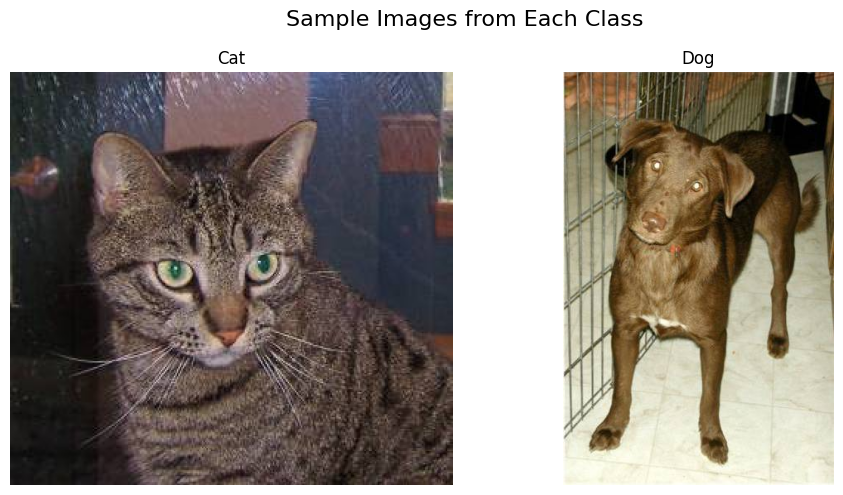

```python
# Define the paths to specific sample files
cat_image_path = new_base_dir / "train" / "cat" / "cat.1.jpg"
dog_image_path = new_base_dir / "train" / "dog" / "dog.1.jpg"

# Open the images
cat_image = Image.open(cat_image_path)
dog_image = Image.open(dog_image_path)

# Plot them
plt.figure(figsize=(10, 5))

plt.subplot(1, 2, 1)
plt.imshow(cat_image)
plt.title("Cat")
plt.axis("off")

plt.subplot(1, 2, 2)
plt.imshow(dog_image)
plt.title("Dog")
plt.axis("off")

plt.suptitle("Sample Images from Each Class", fontsize=16)
plt.tight_layout()
plt.show()
```

The dataset contains 5,000 images, with the following splits: 2,000 images for training, 1,000 for validation, and 2,000 for testing. Each split contains an equal number of cat and dog images.

- Train two networks

```python
train_dataset = image_dataset_from_directory(
    new_base_dir / "train",
    image_size=(180, 180),
    batch_size=32)
validation_dataset = image_dataset_from_directory(
    new_base_dir / "validation",
    image_size=(180, 180),
    batch_size=32)
test_dataset = image_dataset_from_directory(
    new_base_dir / "test",
    image_size=(180, 180),
    batch_size=32)
```

```
Found 2000 files belonging to 2 classes.
Found 1000 files belonging to 2 classes.
Found 2000 files belonging to 2 classes.
```

- Define the first model

```python
inputs = keras.Input(shape=(180, 180, 3))
x = layers.Rescaling(1./255)(inputs)
x = layers.Conv2D(filters=32, kernel_size=3, activation="relu")(x)
x = layers.MaxPooling2D(pool_size=2)(x)
x = layers.Conv2D(filters=64, kernel_size=3, activation="relu")(x)
x = layers.MaxPooling2D(pool_size=2)(x)
x = layers.Conv2D(filters=128, kernel_size=3, activation="relu")(x)
x = layers.MaxPooling2D(pool_size=2)(x)
x = layers.Conv2D(filters=256, kernel_size=3, activation="relu")(x)
x = layers.MaxPooling2D(pool_size=2)(x)
x = layers.Conv2D(filters=256, kernel_size=3, activation="relu")(x)
x = layers.Flatten()(x)
outputs = layers.Dense(1, activation="sigmoid")(x)
model = keras.Model(inputs=inputs, outputs=outputs)


model.compile(loss="binary_crossentropy",
              optimizer="rmsprop",
              metrics=["accuracy", "Precision", "Recall"])
```

- Train the model

```python
callbacks = [
    keras.callbacks.ModelCheckpoint(
        filepath="./models/convnet_from_scratch.keras",
        save_best_only=True,
        monitor="val_loss")
]
history = model.fit(
    train_dataset,
    epochs=15,
    validation_data=validation_dataset,
    callbacks=callbacks)
```

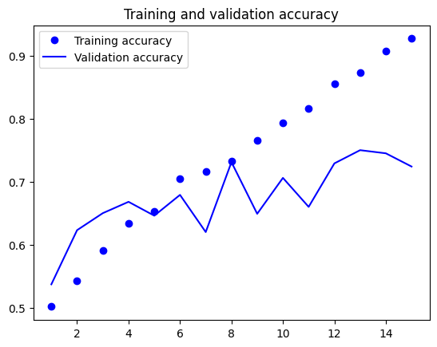

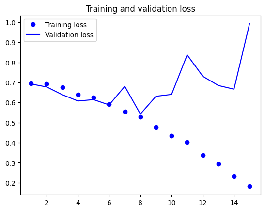

```python
accuracy = history.history["accuracy"]
val_accuracy = history.history["val_accuracy"]
loss = history.history["loss"]
val_loss = history.history["val_loss"]
epochs = range(1, len(accuracy) + 1)
plt.plot(epochs, accuracy, "bo", label="Training accuracy")
plt.plot(epochs, val_accuracy, "b", label="Validation accuracy")
plt.title("Training and validation accuracy")
plt.legend()
plt.figure()
plt.plot(epochs, loss, "bo", label="Training loss")
plt.plot(epochs, val_loss, "b", label="Validation loss")
plt.title("Training and validation loss")
plt.legend()
plt.show()
```

- Training Loss : Decreases smoothly and consistently with each epoch, this indicates that the model is learning well on the training data.
- Validation Loss : Starts increasing significantly after around epoch 8, showing clear signs of overfitting.
- Evaluate the model

```python
test_model = keras.models.load_model("./models/convnet_from_scratch.keras")


test_loss, test_accuracy, test_precision, test_recall = test_model.evaluate(test_dataset)

print(f"Test Loss: {test_loss:.4f}")
print(f"Test Accuracy: {test_accuracy:.4f}")
print(f"Test Precision: {test_precision:.4f}")
print(f"Test Recall: {test_recall:.4f}")
```

```
Test Loss: 0.5491
Test Accuracy: 0.7285
Test Precision: 0.7449
Test Recall: 0.6950
```

- Explore the perfromance metrics

```python
# Initialize empty lists to store true labels and predicted probabilities
y_true = []
y_pred_prob = []

# Iterate over the test dataset to collect true labels and predicted probabilities
for images, labels in test_dataset:
    # Append true labels directly to the list
    y_true.append(labels.numpy())
    y_pred_prob_batch = test_model.predict(images)
    y_pred_prob.append(y_pred_prob_batch)

y_true = np.concatenate(y_true, axis=0)  # Concatenate all true labels from the batches
y_pred_prob = np.concatenate(y_pred_prob, axis=0)  # Concatenate all predicted probabilities from the batches

# Convert probabilities to binary predictions (threshold = 0.5)
y_pred = (y_pred_prob > 0.5).astype(int)  # Convert probabilities to binary class predictions

# Compute Precision, Recall, and F1-Score
precision = precision_score(y_true, y_pred)
recall = recall_score(y_true, y_pred)
f1 = f1_score(y_true, y_pred)

# Print the results
print(f"Precision: {precision:.4f}")
print(f"Recall: {recall:.4f}")
print(f"F1-Score: {f1:.4f}")
```

```
Precision: 0.7449
Recall: 0.6950
F1-Score: 0.7191
```

- Confusion Matrix

```python
# Confusion Matrix
cm_cnn = confusion_matrix(y_true, y_pred)
print(f"Confusion Matrix:\n{cm_cnn}")
```

```
Confusion Matrix:
[[762 238]
 [305 695]]
```

- Precision-Recall Curve

```
Precision-Recall : 0.8033
```

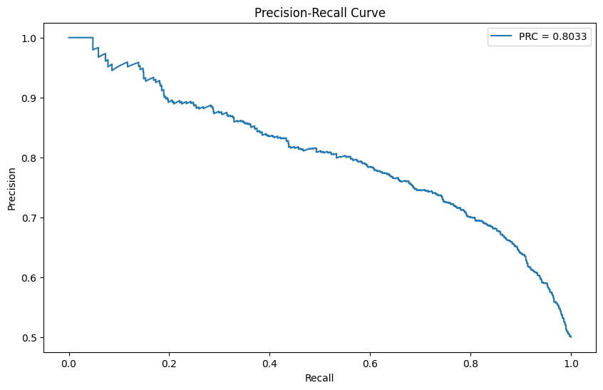

```python
# Precision-Recall Curve
prc_precision, prc_recall, _ = precision_recall_curve(y_true, y_pred_prob)
prc = average_precision_score(y_true, y_pred_prob)
print(f"Precision-Recall : {prc:.4f}")
# Plot Precision-Recall Curve
plt.figure(figsize=(10, 6))
plt.plot(prc_recall, prc_precision, label=f"PRC = {prc:.4f}")
plt.xlabel("Recall")
plt.ylabel("Precision")
plt.title("Precision-Recall Curve")
plt.legend()
plt.show()
```

```python
# Load VGG16 pre-trained on ImageNet
base_model = keras.applications.vgg16.VGG16(
    weights="imagenet",
    include_top=False,
    input_shape=(180, 180, 3)
)

# Freeze the base layers of VGG16
base_model.trainable = False
```

```python
data_folder = pathlib.Path('../data/kaggle_dogs_vs_cats_small')

train_dataset = image_dataset_from_directory(
    data_folder / "train",
    image_size=(180, 180),
    batch_size=32)
validation_dataset = image_dataset_from_directory(
    data_folder / "validation",
    image_size=(180, 180),
    batch_size=32)
test_dataset = image_dataset_from_directory(
    data_folder / "test",
    image_size=(180, 180),
    batch_size=32)
```

```
Found 2000 files belonging to 2 classes.
Found 1000 files belonging to 2 classes.
Found 2000 files belonging to 2 classes.
```

```python
## extracting features from the pre-trained VGG16 model

def get_features_and_labels(dataset):
    all_features = []
    all_labels = []
    for images, labels in dataset:
        preprocessed_images = keras.applications.vgg16.preprocess_input(images)
        features = base_model.predict(preprocessed_images)
        all_features.append(features)
        all_labels.append(labels)
    return np.concatenate(all_features), np.concatenate(all_labels)

train_features, train_labels =  get_features_and_labels(train_dataset)
val_features, val_labels =  get_features_and_labels(validation_dataset)
test_features, test_labels =  get_features_and_labels(test_dataset)
```

- Define and train the model

```python
from tensorflow.keras.layers import Flatten, Dense, Dropout

model1 = keras.Sequential([
    keras.layers.Input(shape=(5, 5, 512)),  # Match the shape of your features
    Flatten(),                              # Flatten the 4D features to 1D
    Dense(256, activation='relu'),
    Dropout(0.5),
    Dense(1, activation='sigmoid')          # Binary classification
])

# Compile the model
model1.compile(loss="binary_crossentropy",
              optimizer="rmsprop",
              metrics=["accuracy", "Precision", "Recall"])

# Define callbacks to monitor overfitting and save the best model
callbacks = [
    ModelCheckpoint(
        filepath="./models/feature_extraction.keras",
        save_best_only=True,
        monitor="val_loss"),  # Save only the best model based on val_loss
]

# Train the model with the extracted features
history = model1.fit(
    train_features, train_labels,
    epochs=10,
    validation_data=(val_features, val_labels),
    callbacks=callbacks  # Include callbacks to track overfitting
)
```

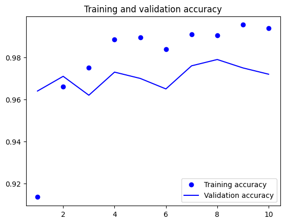

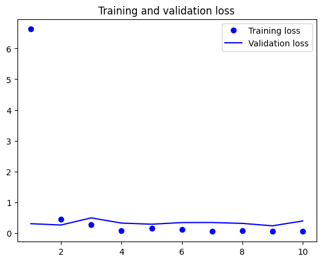

```python
acc = history.history["accuracy"]
val_acc = history.history["val_accuracy"]
loss = history.history["loss"]
val_loss = history.history["val_loss"]
epochs = range(1, len(acc) + 1)
plt.plot(epochs, acc, "bo", label="Training accuracy")
plt.plot(epochs, val_acc, "b", label="Validation accuracy")
plt.title("Training and validation accuracy")
plt.legend()
plt.figure()
plt.plot(epochs, loss, "bo", label="Training loss")
plt.plot(epochs, val_loss, "b", label="Validation loss")
plt.title("Training and validation loss")
plt.legend()
plt.show()
```

- Training loss: Shows consistent and low loss from epoch 4 to 10.
- Validation loss : Remains relatively low and stable throughout all 10 epochs.
- Evaluate the model

```python
test_loss1, test_accuracy1, test_precision1, test_recall1 = model1.evaluate(test_features, test_labels)

print(f"Test Loss: {test_loss1:.4f}")
print(f"Test Accuracy: {test_accuracy1:.4f}")
print(f"Test Precision: {test_precision1:.4f}")
print(f"Test Recall: {test_recall1:.4f}")
```

```
Test Loss: 0.4849
Test Accuracy: 0.9705
Test Precision: 0.9846
Test Recall: 0.9560
```

- Explore the relative performance of the models

```python
# Get the true labels and predicted probabilities for the test data
y_true1 = test_labels
y_pred_prob1 = model1.predict(test_features)  # Get predicted probabilities
y_pred1 = (y_pred_prob1 > 0.5).astype(int)  # Convert probabilities to binary predictions

# Precision, Recall, F1-Score
precision1 = precision_score(y_true1, y_pred1)
recall1 = recall_score(y_true1, y_pred1)
f1_1 = f1_score(y_true1, y_pred1)

print(f"Precision: {precision1:.4f}")
print(f"Recall: {recall1:.4f}")
print(f"F1-Score: {f1_1:.4f}")
```

```
Precision: 0.9846
Recall: 0.9560
F1-Score: 0.9701
```

- Confusion matrix

```python
# Confusion Matrix
cm_vgg = confusion_matrix(y_true1, y_pred1)
print(f"Confusion Matrix:\n{cm_vgg}")
```

```
Confusion Matrix:
[[985  15]
 [ 44 956]]
```

- Precision- recall curve

```
Precision-Recall AUC: 0.9927
```

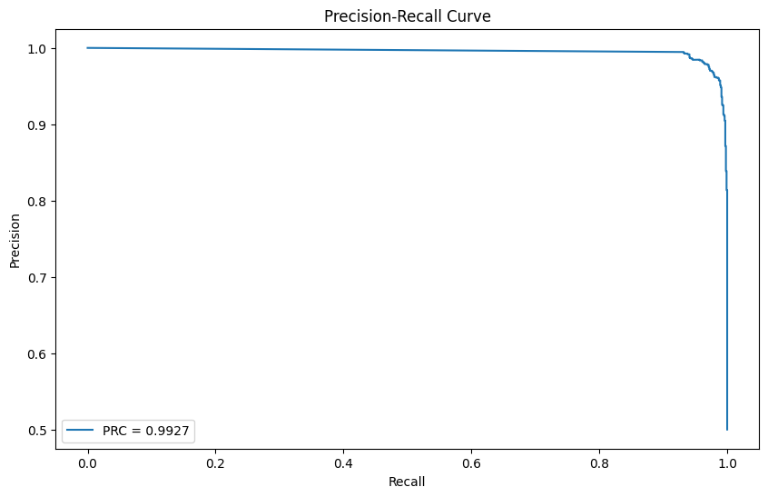

```python
# Precision-Recall Curve
prc_precision, prc_recall, _ = precision_recall_curve(y_true1, y_pred_prob1)
prc1 = average_precision_score(y_true1, y_pred_prob1)
print(f"Precision-Recall AUC: {prc1:.4f}")

# Optional: Plot Precision-Recall Curve
plt.figure(figsize=(10, 6))
plt.plot(prc_recall, prc_precision, label=f"PRC = {prc1:.4f}")
plt.xlabel("Recall")
plt.ylabel("Precision")
plt.title("Precision-Recall Curve")
plt.legend()
plt.show()
```

## Conclusion

1. First Model Performance:
- Precision: 0.7449
- Recall: 0.6950
- F1-Score: 0.7191

Confusion Matrix:

- True Negatives (TN): 762
- False Positives (FP): 238
- False Negatives (FN): 305
- True Positives (TP): 695

Precision-Recall AUC: 0.8033

Test Loss: 0.5491

Test Accuracy: 0.7285

2. Second Model Performance:
- Precision: 0.9846
- Recall: 0.9560
- F1-Score: 0.9701

Confusion Matrix:

- True Negatives (TN): 985
- False Positives (FP): 15
- False Negatives (FN): 44
- True Positives (TP): 956

Precision-Recall AUC: 0.9927

Test Loss: 0.4849

Test Accuracy: 0.9705

The second model, which uses VGG16 for feature extraction, performs significantly better than the first model, with notably higher precision, recall, and F1-score. The confusion matrix shows very few false positives and false negatives, indicating excellent performance in distinguishing between cats and dogs. The Precision-Recall AUC of 0.9927 reflects outstanding balance and overall classification ability.